# Inference about the bias of a coin

# The posterior depends on the priors when observations are few ($y$=1 tails, $n$=2, heads=1)

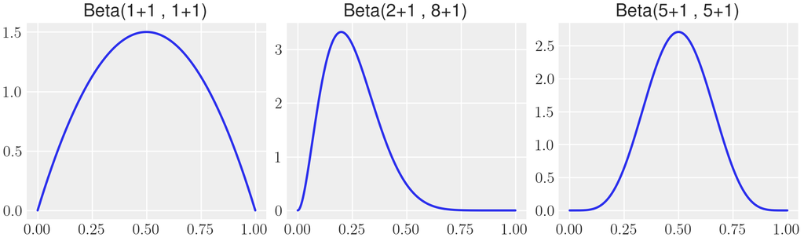

- The Beta(2,8) represents the following beliefs:
  - expected value = $\frac{2}{2+8}=0.2$

```python
from scipy.stats import beta
quantiles=[0.05, 0.25, 0.5, 0.75, 0.95]
q = beta.ppf(quantiles, a=2, b=8)
print(q)
```

```
## [0.04102317 0.10716259 0.17961961 0.27226945 0.42913555]
```

# The posterior becomes similar as we observe more data (10 tails, 12 heads)

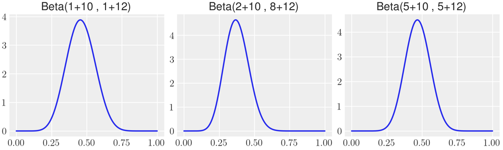

# When the number of observations is large, the posterior is the same whatever the prior

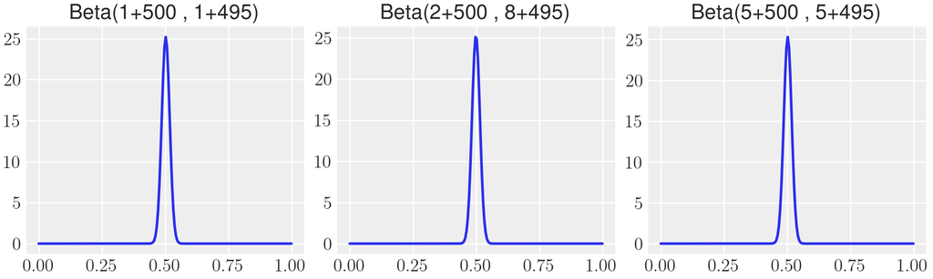

The posterior means $E_{\text{post}}[\theta]$ obtained using the different priors are:

- $\frac{500+1}{500+1+495+1}=\frac{501}{997}=0.502$
- $\frac{500+2}{500+2+495+8}=\frac{502}{1005}=0.499$
- $\frac{500+5}{500+5+495+5}=\frac{505}{1005}=0.502$
- Also the posterior variances and quantiles are practically identical in the different cases.
- The likelihood *overwhelms* the prior.

# The posterior mean is just part of the information

- The result of the Bayesian analysis is the posterior distribution of $\theta$, **not** a single value.
- The dispersion of the posterior distribution (posterior variance) is a measure of our uncertainty.
- The uncertainty decreases when the number of experiments is greater.
- Given a large amount of data, the posterior is practically the same with any prior, but how much data is needed varies with the problem.
- If we only have few data, the posterior can differ depending on the adopted prior; it makes sense to repeat the analysis with different priors (*sensitivity*).
- This is sensible: the prior encodes our previous knowledge and different experts could have different priors.

# Discussion

- Priors and likelihood are assumptions which are part of the model.
- Uninformative priors (flat) provide the least possible amount of information and therefore have the least possible impact on the analysis.
- *Slightly informative* priors are recommended, which at least provide the order of magnitude of the parameter.
- In many cases we known that the parameter can only be positive, or that they are restricted to sum to 1 or the approximate range, etc.
- For instance even a Beta(1,1) prior is flat but limits the possible values of $\theta$ between 0 and 1.

# Conclusions

- We have seen how Bayesian inference works when Bayes’ rule can be solved analytically, i.e., when the likelihood has a conjugate prior distribution.
- In this case the posterior distribution has the same mathematical form as the prior.
- Only simple likelihood functions have conjugate priors. In realistic applications the complex models have no conjugate priors. We will abandon exact mathematical solutions to use instead use numerical Markov chain Monte Carlo (MCMC) methods.